# ModelodeRegresionLogistica

MODELO DE REGRESIÓN LOGISTICA

La regresión logística es un método estadístico que trata de modelar la probabilidad de una variable cualitativa binaria (dos posibles valores) en función de una o más variables independientes. La principal aplicación de la regresión logística es la creación de modelos de clasificación binaria.

Se llama regresión logística simple cuando solo hay una variable independiente y regresión logística múltiple cuando hay más de una. Dependiendo del contexto, a la variable modelada se le conoce como variable dependiente o variable respuesta, y a las variables independientes como regresores, predictores o features.

Un estudio quiere establecer un modelo que permita calcular la probabilidad de averiguar si Mujeres indias pime de 21 años o más que viven en Phoenix, la quinta ciudad más grande del estado de Arizona en EE.UU padecen o no diabetes, los datos usados para la investigacion se conservan en los Institutos Nacionales de Diabetes, Enfermedades Digestivas y Renales de EE.UU.. La variable objetivo se especifica como "resultado"; está codificada como: 1 si el resultado de la prueba de diabetes indica positivo y 0 si el resultado de la prueba de diabetes indica negativo.

Variables

Embarazos: Número de embarazos

Glucosa: Glucosa.

PresiónArterial: Presión arterial. BloodPressure

SkinThickness: Grosor de la piel

Insulina: Insulina.

IMC: Índice de masa corporal.

DiabetesPedigreeFunction: una función que calcula la probabilidad de tener diabetes según la edad de las personas y sus antecedentes familiares diabéticos.

Edad: Edad (años)

Resultado: Información sobre si la persona tiene diabetes o no. Tener la enfermedad (1) o no (0)

Para esta investigacion de llevaran a acabo los siguientes procesos:

```python
# Importar Librerias
import matplotlib.pyplot as plt
import numpy as np
import pandas as pd
pd.options.display.max_seq_items = 2000
import seaborn as sns
import os # directorios de trabajo

from sklearn.preprocessing import RobustScaler
from sklearn.linear_model import LogisticRegression
from sklearn.metrics import accuracy_score, roc_auc_score, confusion_matrix, classification_report
from sklearn.model_selection import train_test_split, cross_validate
from sklearn.metrics import roc_curve, auc

pd.set_option('display.max_columns', None)
pd.set_option('display.float_format', lambda x: '%.3f' % x)
pd.set_option('display.width', 500)
```

```python
# Definir funciones

def outlier_thresholds(dataframe, col_name, q1=0.05, q3=0.95):
    quartile1 = dataframe[col_name].quantile(q1)
    quartile3 = dataframe[col_name].quantile(q3)
    interquantile_range = quartile3 - quartile1
    low_limit = quartile1 - 1.5 * interquantile_range
    up_limit = quartile3 + 1.5 * interquantile_range
    return low_limit, up_limit

def check_outlier(dataframe, col_name):
    low_limit, up_limit = outlier_thresholds(dataframe, col_name)
    if dataframe[(dataframe[col_name] < low_limit) | (dataframe[col_name] > up_limit)].any(axis=None):
        return True
    else:
        return False

def replace_with_thresholds(dataframe, variable):
    low_limit, up_limit = outlier_thresholds(dataframe, variable)
    dataframe.loc[(dataframe[variable] < low_limit), variable] = low_limit
    dataframe.loc[(dataframe[variable] > up_limit), variable] = up_limit
```

```python
# Establecer directorio de trabajo (working directory) e importar el Dataframe forbes23

os.getcwd()
```

```
'c:\\Users\\USUARIO\\OneDrive\\Documentos\\Uibero Ing de Software\\8 SEMESTRE\\Inteligencia_artificial-main'
```

```python
# Mostrar los Archivos que hay en el ditrectorio de trabajo
os.listdir()
```

```
['.git',
 '1. Introduccion.ipynb',
 '2. Numpy.ipynb',
 '3. PandasForbes.ipynb',
 'Aactividad 1.docx',
 'caracteristicas de vinos.csv',
 'cluster_k-means.html',
 'cluster_k-means.ipynb',
 'cluster_k-significa.pdf',
 'Diabetes',
 'Explicacion del modelo kmeans.ipynb',
 'Forbes',
 'forbes23.ipynb',
 'forbes23AarbolDecisiones.ipynb',
 'image-1.png',
 'image.png',
 'inteligencia-artificial-metodos-tecnicas-y-aplicaciones.pdf',
 'ipynb',
 'Kmeansforbes2023',
 'Mall_Customers.csv',
 'modelo Kmeans forbes 2023.docx',
 'ModelodeRegresionLogistica.ipynb',
 'Project kmeans customer.ipynb',
 'pruebaforbes.ipynb']
```

Exploratory Data Analysis - Análisis exploratorio de datos

```python
# Importar la base de datos
diabetes = pd.read_csv(r"C:\Users\USUARIO\OneDrive\Documentos\Uibero Ing de Software\8 SEMESTRE\Inteligencia_artificial-main\Diabetes\diabetes.csv")
diabetes.head()
```

|  | Pregnancies | Glucose | BloodPressure | SkinThickness | Insulin | BMI | DiabetesPedigreeFunction | Age | Outcome |
| --- | --- | --- | --- | --- | --- | --- | --- | --- | --- |
| 0 | 6 | 148 | 72 | 35 | 0 | 33.600 | 0.627 | 50 | 1 |
| 1 | 1 | 85 | 66 | 29 | 0 | 26.600 | 0.351 | 31 | 0 |
| 2 | 8 | 183 | 64 | 0 | 0 | 23.300 | 0.672 | 32 | 1 |
| 3 | 1 | 89 | 66 | 23 | 94 | 28.100 | 0.167 | 21 | 0 |
| 4 | 0 | 137 | 40 | 35 | 168 | 43.100 | 2.288 | 33 | 1 |

```python
# muestra las columnas del DataFrame.
print(diabetes.columns)
```

```
Index(['Pregnancies', 'Glucose', 'BloodPressure', 'SkinThickness', 'Insulin', 'BMI', 'DiabetesPedigreeFunction', 'Age', 'Outcome'], dtype='object')
```

Target Analysis - Análisis del objetivo de la investigacion

```
Outcome
0   65.104
1   34.896
Name: count, dtype: float64
```

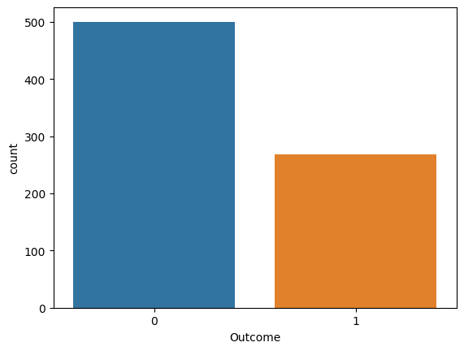

```python
diabetes["Outcome"].value_counts()  # Outcome = resultado de si tiene o no la enfermedad

print(100 * diabetes["Outcome"].value_counts() / len(diabetes)) # formula para saber cuantas indias pime tienen o no diabetes

sns.countplot(x="Outcome", data=diabetes) # se grafica
plt.show()
```

Feature'ların Analizi - Análisis de características

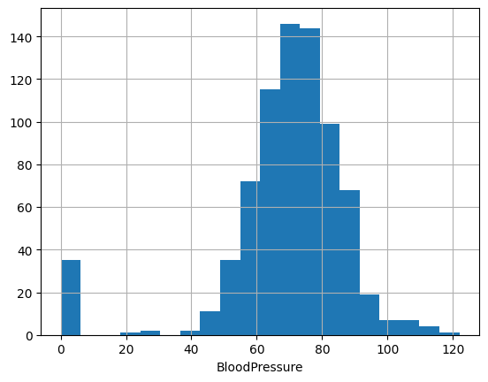

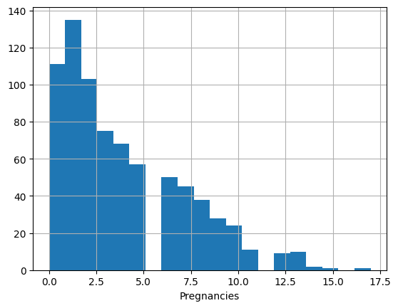

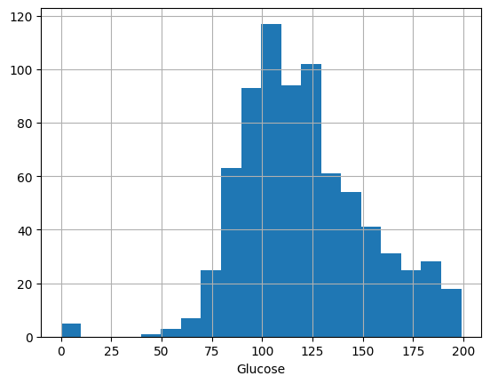

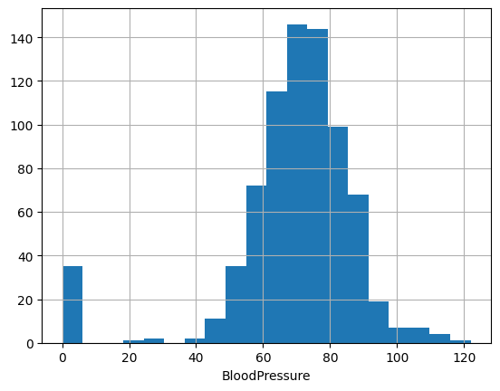

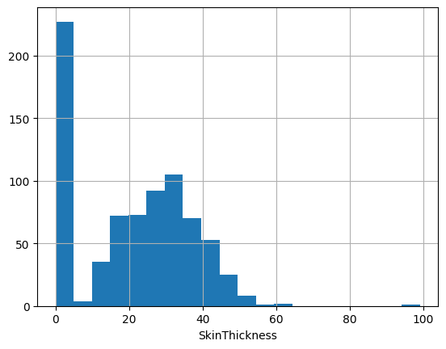

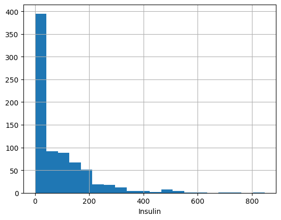

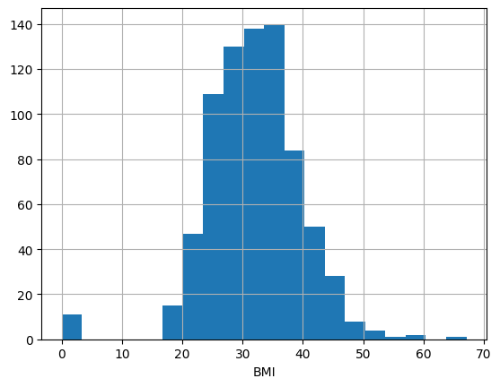

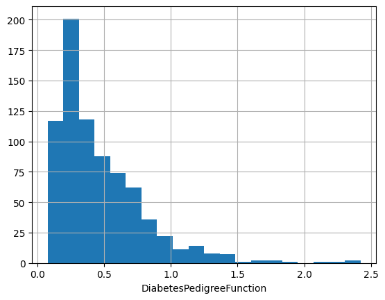

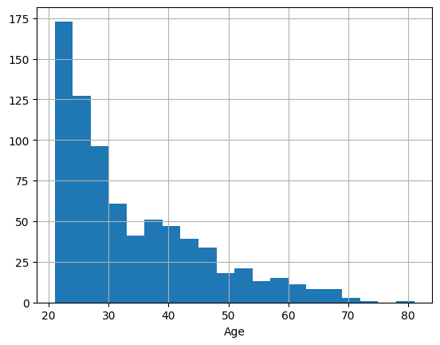

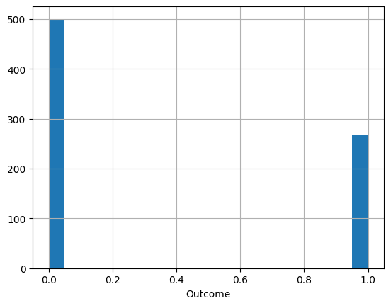

```python
diabetes["BloodPressure"].hist(bins=20)  # caracteristica BloodPressure = presión arterial se hace histograma
plt.xlabel("BloodPressure")
plt.show()

def plot_numerical_col(dataframe, numerical_col):  # se hace histogramacon todas las carateristicas
    dataframe[numerical_col].hist(bins=20)
    plt.xlabel(numerical_col)
    plt.show()

for col in diabetes.columns:                  # se grafica
    plot_numerical_col(diabetes, col)
```

```python
cols = [col for col in diabetes.columns if "Outcome" not in col]

# for col in cols:  se reviasn datos estadisticos de las caracteristicas o columnas
# plot_numerical_col(diabetes, col)

diabetes.describe().T
```

|  | count | mean | std | min | 25% | 50% | 75% | max |
| --- | --- | --- | --- | --- | --- | --- | --- | --- |
| Pregnancies | 768.000 | 3.845 | 3.370 | 0.000 | 1.000 | 3.000 | 6.000 | 17.000 |
| Glucose | 768.000 | 120.895 | 31.973 | 0.000 | 99.000 | 117.000 | 140.250 | 199.000 |
| BloodPressure | 768.000 | 69.105 | 19.356 | 0.000 | 62.000 | 72.000 | 80.000 | 122.000 |
| SkinThickness | 768.000 | 20.536 | 15.952 | 0.000 | 0.000 | 23.000 | 32.000 | 99.000 |
| Insulin | 768.000 | 79.799 | 115.244 | 0.000 | 0.000 | 30.500 | 127.250 | 846.000 |
| BMI | 768.000 | 31.993 | 7.884 | 0.000 | 27.300 | 32.000 | 36.600 | 67.100 |
| DiabetesPedigreeFunction | 768.000 | 0.472 | 0.331 | 0.078 | 0.244 | 0.372 | 0.626 | 2.420 |
| Age | 768.000 | 33.241 | 11.760 | 21.000 | 24.000 | 29.000 | 41.000 | 81.000 |
| Outcome | 768.000 | 0.349 | 0.477 | 0.000 | 0.000 | 0.000 | 1.000 | 1.000 |

Target vs Features - Objetivo de la investigacion frente a las características

```python
diabetes.groupby("Outcome").agg({"Pregnancies" : "mean"}) # se agrupan los resultados segun mujeres embarazadas y la media

def target_summary_with_num(dataframe, target, numerical_col): # se define la funcion para todas las clumnas
    print(dataframe.groupby(target).agg({numerical_col: "mean"}) , end="\n\n\n") # se imprime el resultado

for col in cols:         # se aplica el cilco for para todas las columnas
    target_summary_with_num(diabetes, "Outcome", col)
```

```
         Pregnancies
Outcome
0              3.298
1              4.866


         Glucose
Outcome
0        109.980
1        141.257


         BloodPressure
Outcome
0               68.184
1               70.825


         SkinThickness
Outcome
0               19.664
1               22.164


         Insulin
Outcome
0         68.792
1        100.336


           BMI
Outcome
0       30.304
1       35.143


         DiabetesPedigreeFunction
Outcome
0                           0.430
1                           0.550


           Age
Outcome
0       31.190
1       37.067
```